# 6912_final_project_March_21

**CUSTOMER ATTRITION PREDICTION MODEL USING MACHINE LEARNING**

```python
import pandas as pd

data = pd.read_csv('BankChurners.csv')
data=data.drop(columns=['CLIENTNUM', 'Naive_Bayes_Classifier_Attrition_Flag_Card_Category_Contacts_Count_12_mon_Dependent_count_Education_Level_Months_Inactive_12_mon_1', 'Naive_Bayes_Classifier_Attrition_Flag_Card_Category_Contacts_Count_12_mon_Dependent_count_Education_Level_Months_Inactive_12_mon_2'])
data.head()
```

|  | Attrition_Flag | Customer_Age | Gender | Dependent_count | Education_Level | Marital_Status | Income_Category | Card_Category | Months_on_book | Total_Relationship_Count | Months_Inactive_12_mon | Contacts_Count_12_mon | Credit_Limit | Total_Revolving_Bal | Avg_Open_To_Buy | Total_Amt_Chng_Q4_Q1 | Total_Trans_Amt | Total_Trans_Ct | Total_Ct_Chng_Q4_Q1 | Avg_Utilization_Ratio |
| --- | --- | --- | --- | --- | --- | --- | --- | --- | --- | --- | --- | --- | --- | --- | --- | --- | --- | --- | --- | --- |
| 0 | Existing Customer | 45 | M | 3 | High School | Married | $60K - $80K | Blue | 39 | 5 | 1 | 3 | 12691.0 | 777 | 11914.0 | 1.335 | 1144 | 42 | 1.625 | 0.061 |
| 1 | Existing Customer | 49 | F | 5 | Graduate | Single | Less than $40K | Blue | 44 | 6 | 1 | 2 | 8256.0 | 864 | 7392.0 | 1.541 | 1291 | 33 | 3.714 | 0.105 |
| 2 | Existing Customer | 51 | M | 3 | Graduate | Married | $80K - $120K | Blue | 36 | 4 | 1 | 0 | 3418.0 | 0 | 3418.0 | 2.594 | 1887 | 20 | 2.333 | 0.000 |
| 3 | Existing Customer | 40 | F | 4 | High School | Unknown | Less than $40K | Blue | 34 | 3 | 4 | 1 | 3313.0 | 2517 | 796.0 | 1.405 | 1171 | 20 | 2.333 | 0.760 |
| 4 | Existing Customer | 40 | M | 3 | Uneducated | Married | $60K - $80K | Blue | 21 | 5 | 1 | 0 | 4716.0 | 0 | 4716.0 | 2.175 | 816 | 28 | 2.500 | 0.000 |

**Perform EDA(Explory data analysis) to check the attrited ratio among different columns**

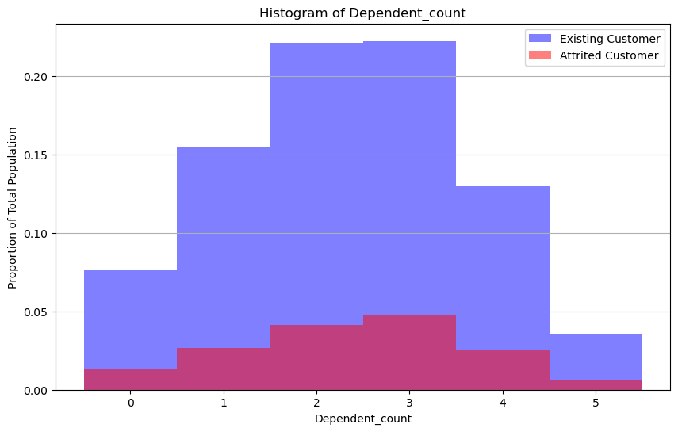

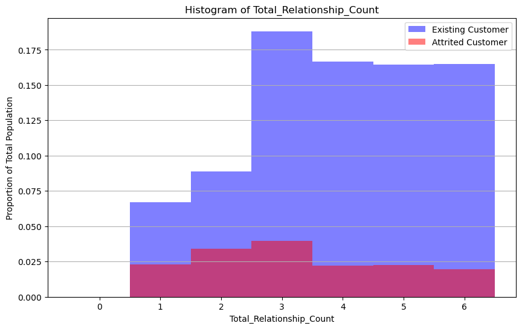

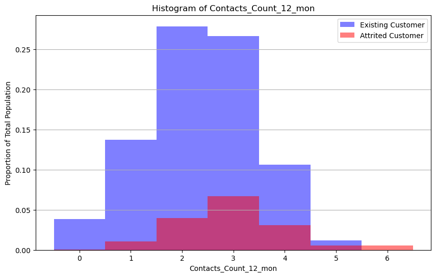

```python
import pandas as pd
import matplotlib.pyplot as plt
import numpy as np

# Specified numerical columns to visualize
columns = [
    'Dependent_count', 'Total_Relationship_Count', 'Contacts_Count_12_mon'
]

# Total number of customers
total_customers = len(data)

# Loop through each specified column
for column in columns:
    # Set up the plot
    plt.figure(figsize=(10, 6))

    # Find the maximum value for the current column to define bin edges
    max_value = data[column].max()
    bins = np.arange(0, max_value + 2) - 0.5  # Shift bins to center integers

    # Plot histogram for Existing Customers
    ec_data = data[data['Attrition_Flag'] == 'Existing Customer'][column]
    counts, _, _ = plt.hist(ec_data, bins=bins, color='blue', alpha=0.5, label='Existing Customer', weights=np.ones(len(ec_data)) / total_customers)

    # Plot histogram for Attrited Customers
    ac_data = data[data['Attrition_Flag'] == 'Attrited Customer'][column]
    plt.hist(ac_data, bins=bins, color='red', alpha=0.5, label='Attrited Customer', weights=np.ones(len(ac_data)) / total_customers)

    # Beautify the plot
    plt.xticks(range(max_value + 1))
    plt.title(f'Histogram of {column}')
    plt.xlabel(column)
    plt.ylabel('Proportion of Total Population')
    plt.legend()
    plt.grid(axis='y')
    plt.show()
```

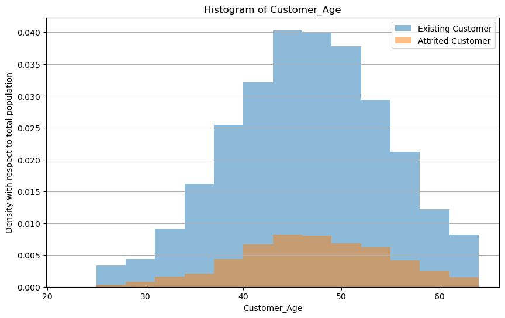

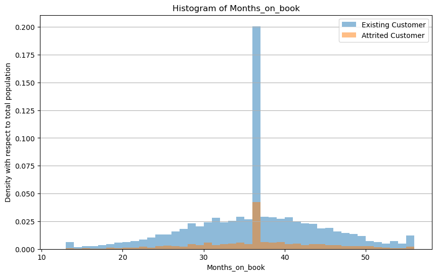

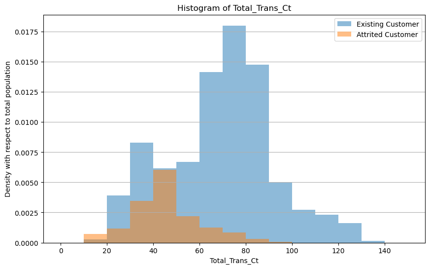

```python
import pandas as pd
import matplotlib.pyplot as plt
import numpy as np

# Define the custom bins for each variable
bins_customer_age = np.arange(22, 67, 3)  # Age bins from 22 to 66 with an interval of 3
bins_months_on_book = np.arange(12, 57, 1)  # Months on book from 12 to 56 with an interval of 1
bins_total_trans_ct = np.arange(0, 151, 10)  # Total_Trans_Ct from 0 to 140 with an interval of 10

# A dictionary to map columns to their custom bins
custom_bins = {
    'Customer_Age': bins_customer_age,
    'Months_on_book': bins_months_on_book,
    'Total_Trans_Ct': bins_total_trans_ct,
}

# Total number of customers
total_customers = len(data)

# Loop through each specified column
for column, bins in custom_bins.items():
    # Set up the plot
    plt.figure(figsize=(10, 6))

    # Get the data for each group
    group_data = {
        'Existing Customer': data[data['Attrition_Flag'] == 'Existing Customer'][column],
        'Attrited Customer': data[data['Attrition_Flag'] == 'Attrited Customer'][column]
    }

    # Plot histograms for each group
    for group, values in group_data.items():
        # Calculate the density for the group
        density, _ = np.histogram(values, bins=bins, density=True)
        # Calculate the weighted density based on total population
        weighted_density = density * (len(values) / total_customers)
        # Plot the weighted density as a histogram
        plt.bar(bins[:-1], weighted_density, width=np.diff(bins), label=group, alpha=0.5, align='edge')

    # Beautify the plot
    plt.title(f'Histogram of {column}')
    plt.xlabel(column)
    plt.ylabel('Density with respect to total population')
    plt.legend()
    plt.grid(axis='y')
    plt.show()
```

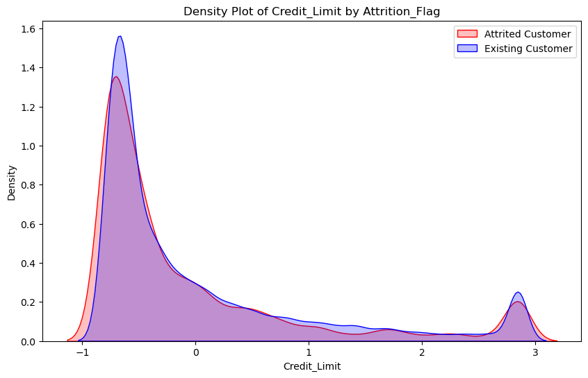

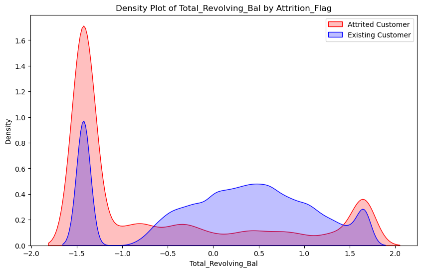

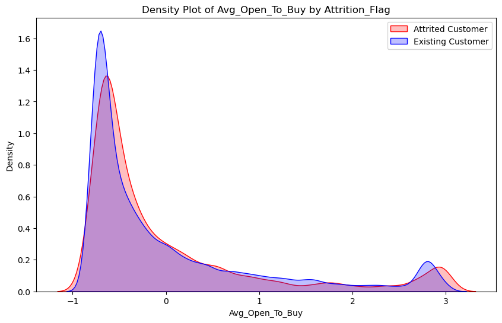

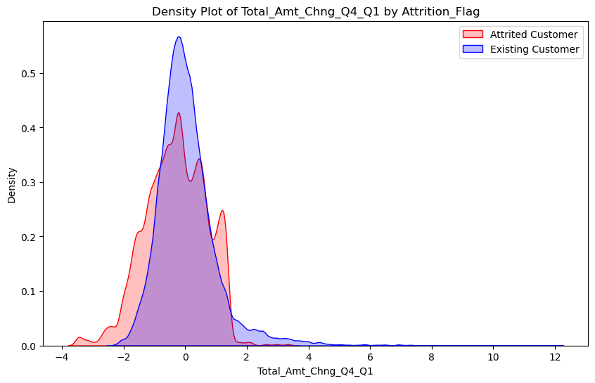

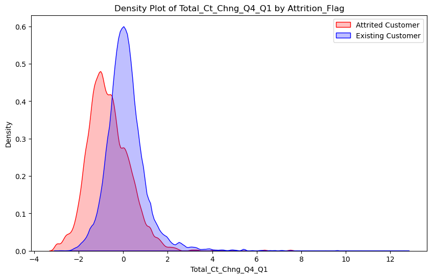

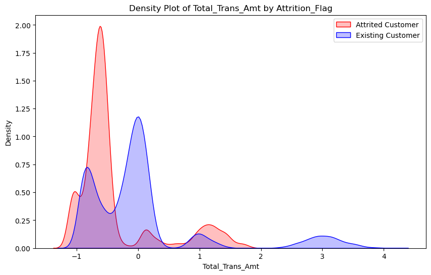

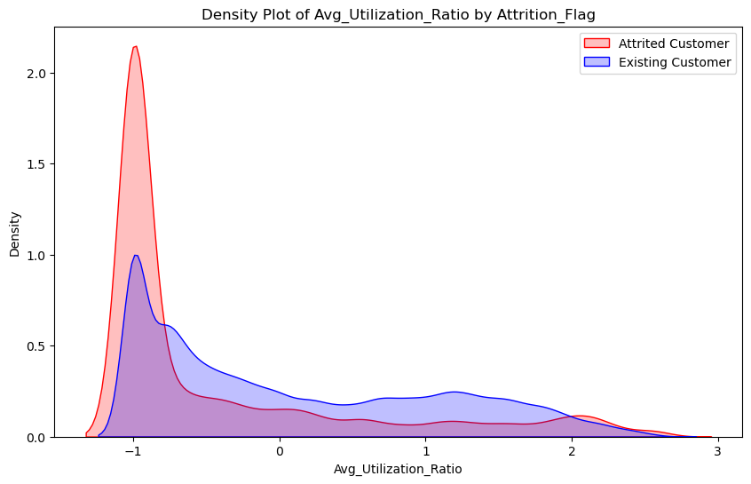

```python
import pandas as pd
import matplotlib.pyplot as plt
import seaborn as sns
import numpy as np

float_columns = [
    'Credit_Limit', 'Total_Revolving_Bal', 'Avg_Open_To_Buy', 'Total_Amt_Chng_Q4_Q1',
    'Total_Ct_Chng_Q4_Q1', 'Total_Trans_Amt', 'Avg_Utilization_Ratio'
]

# Total number of customers
total_customers = len(data)

# Loop over each numerical column
for column in float_columns:
    plt.figure(figsize=(10, 6))

    # For Attrited Customers: Calculate density considering the total population
    sns.kdeplot(
        data=data[data['Attrition_Flag'] == 'Attrited Customer'],
        x=column,
        color='red',
        label='Attrited Customer',
        fill=True,
        bw_adjust=0.5,
        common_norm=False,  # This ensures the density is relative to the total population
        weights=np.ones(len(data[data['Attrition_Flag'] == 'Attrited Customer'])) / total_customers
    )

    # For Existing Customers: Calculate density considering the total population
    sns.kdeplot(
        data=data[data['Attrition_Flag'] == 'Existing Customer'],
        x=column,
        color='blue',
        label='Existing Customer',
        fill=True,
        bw_adjust=0.5,
        common_norm=False,  # This ensures the density is relative to the total population
        weights=np.ones(len(data[data['Attrition_Flag'] == 'Existing Customer'])) / total_customers
    )

    plt.title(f'Density Plot of {column} by Attrition_Flag')
    plt.xlabel(column)
    plt.ylabel('Density')
    plt.legend()
    plt.show()
```

```python
data
```

|  | Attrition_Flag | Customer_Age | Gender | Dependent_count | Education_Level | Marital_Status | Income_Category | Card_Category | Months_on_book | Total_Relationship_Count | Months_Inactive_12_mon | Contacts_Count_12_mon | Credit_Limit | Total_Revolving_Bal | Avg_Open_To_Buy | Total_Amt_Chng_Q4_Q1 | Total_Trans_Amt | Total_Trans_Ct | Total_Ct_Chng_Q4_Q1 | Avg_Utilization_Ratio |
| --- | --- | --- | --- | --- | --- | --- | --- | --- | --- | --- | --- | --- | --- | --- | --- | --- | --- | --- | --- | --- |
| 0 | Existing Customer | 45 | M | 3 | High School | Married | $60K - $80K | Blue | 39 | 5 | 1 | 3 | 12691.0 | 777 | 11914.0 | 1.335 | 1144 | 42 | 1.625 | 0.061 |
| 1 | Existing Customer | 49 | F | 5 | Graduate | Single | Less than $40K | Blue | 44 | 6 | 1 | 2 | 8256.0 | 864 | 7392.0 | 1.541 | 1291 | 33 | 3.714 | 0.105 |
| 2 | Existing Customer | 51 | M | 3 | Graduate | Married | $80K - $120K | Blue | 36 | 4 | 1 | 0 | 3418.0 | 0 | 3418.0 | 2.594 | 1887 | 20 | 2.333 | 0.000 |
| 3 | Existing Customer | 40 | F | 4 | High School | Unknown | Less than $40K | Blue | 34 | 3 | 4 | 1 | 3313.0 | 2517 | 796.0 | 1.405 | 1171 | 20 | 2.333 | 0.760 |
| 4 | Existing Customer | 40 | M | 3 | Uneducated | Married | $60K - $80K | Blue | 21 | 5 | 1 | 0 | 4716.0 | 0 | 4716.0 | 2.175 | 816 | 28 | 2.500 | 0.000 |
| ... | ... | ... | ... | ... | ... | ... | ... | ... | ... | ... | ... | ... | ... | ... | ... | ... | ... | ... | ... | ... |
| 10122 | Existing Customer | 50 | M | 2 | Graduate | Single | $40K - $60K | Blue | 40 | 3 | 2 | 3 | 4003.0 | 1851 | 2152.0 | 0.703 | 15476 | 117 | 0.857 | 0.462 |
| 10123 | Attrited Customer | 41 | M | 2 | Unknown | Divorced | $40K - $60K | Blue | 25 | 4 | 2 | 3 | 4277.0 | 2186 | 2091.0 | 0.804 | 8764 | 69 | 0.683 | 0.511 |
| 10124 | Attrited Customer | 44 | F | 1 | High School | Married | Less than $40K | Blue | 36 | 5 | 3 | 4 | 5409.0 | 0 | 5409.0 | 0.819 | 10291 | 60 | 0.818 | 0.000 |
| 10125 | Attrited Customer | 30 | M | 2 | Graduate | Unknown | $40K - $60K | Blue | 36 | 4 | 3 | 3 | 5281.0 | 0 | 5281.0 | 0.535 | 8395 | 62 | 0.722 | 0.000 |
| 10126 | Attrited Customer | 43 | F | 2 | Graduate | Married | Less than $40K | Silver | 25 | 6 | 2 | 4 | 10388.0 | 1961 | 8427.0 | 0.703 | 10294 | 61 | 0.649 | 0.189 |

10127 rows × 20 columns

## Preprocess the Data

```python
# Factorize Categorical Variables
categorical_vars = ['Gender', 'Education_Level', 'Marital_Status', 'Income_Category', 'Card_Category']
for var in categorical_vars:
    data[var], _ = pd.factorize(data[var])

# Standardize Decimal Variables
from sklearn.preprocessing import StandardScaler

decimal_vars = ['Credit_Limit', 'Total_Revolving_Bal', 'Avg_Open_To_Buy', 'Total_Amt_Chng_Q4_Q1', 'Total_Trans_Amt', 'Total_Ct_Chng_Q4_Q1', 'Avg_Utilization_Ratio']
scaler = StandardScaler()
data[decimal_vars] = scaler.fit_transform(data[decimal_vars])

# Split Data into Training, Validation, and Test Sets
from sklearn.model_selection import train_test_split

X = data.drop('Attrition_Flag', axis=1)
y, _ = pd.factorize(data['Attrition_Flag'])  # Convert to 0,1 for model training

# Splitting data into 60% training, 20% validation, 20% test
X_train, X_temp, y_train, y_temp = train_test_split(X, y, test_size=0.4, random_state=42)
X_val, X_test, y_val, y_test = train_test_split(X_temp, y_temp, test_size=0.5, random_state=42)
```

### Fit a SVM model

```
              precision    recall  f1-score   support

           0       0.92      0.97      0.95      1693
           1       0.81      0.56      0.66       333

    accuracy                           0.91      2026
   macro avg       0.86      0.77      0.80      2026
weighted avg       0.90      0.91      0.90      2026
```

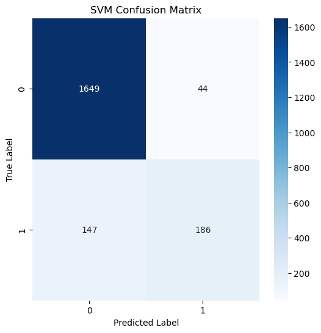

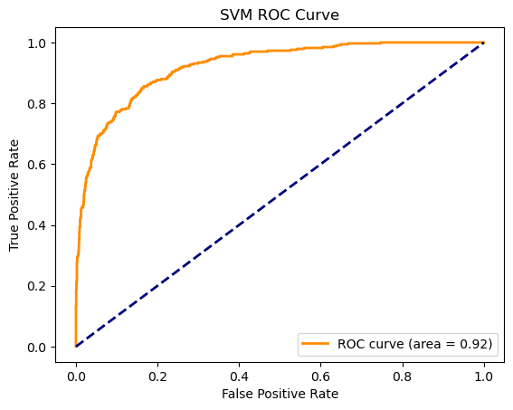

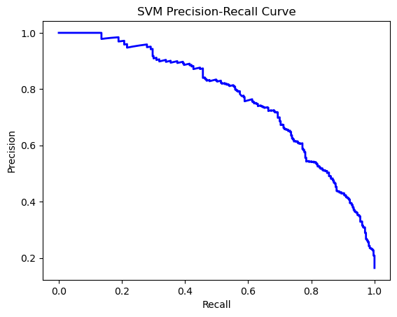

```python
from sklearn.svm import SVC
from sklearn.metrics import accuracy_score, confusion_matrix, classification_report
from sklearn.metrics import roc_curve, auc, precision_recall_curve
import matplotlib.pyplot as plt
import seaborn as sns

# Fit the SVM model
svm_model = SVC(kernel='linear', probability=True)  # Using a linear kernel and enabling probability estimates
svm_model.fit(X_train, y_train)

# Predict on the test data
y_pred_svm = svm_model.predict(X_test)
y_probs_svm = svm_model.predict_proba(X_test)[:, 1]

# Performance evaluation
# Confusion matrix
conf_matrix_svm = confusion_matrix(y_test, y_pred_svm)

# ROC curve
fpr_svm, tpr_svm, _ = roc_curve(y_test, y_probs_svm)
roc_auc_svm = auc(fpr_svm, tpr_svm)

# Precision-recall curve
precision_svm, recall_svm, _ = precision_recall_curve(y_test, y_probs_svm)

# Classification report
report_svm = classification_report(y_test, y_pred_svm)

# Plotting
# Confusion matrix
plt.figure(figsize=(6, 6))
sns.heatmap(conf_matrix_svm, annot=True, fmt='d', cmap=plt.cm.Blues)
plt.title('SVM Confusion Matrix')
plt.ylabel('True Label')
plt.xlabel('Predicted Label')

# ROC curve
plt.figure()
plt.plot(fpr_svm, tpr_svm, color='darkorange', lw=2, label='ROC curve (area = %0.2f)' % roc_auc_svm)
plt.plot([0, 1], [0, 1], color='navy', lw=2, linestyle='--')
plt.title('SVM ROC Curve')
plt.xlabel('False Positive Rate')
plt.ylabel('True Positive Rate')
plt.legend(loc="lower right")

# Precision-recall curve
plt.figure()
plt.plot(recall_svm, precision_svm, color='blue', lw=2)
plt.title('SVM Precision-Recall Curve')
plt.xlabel('Recall')
plt.ylabel('Precision')

# Print classification report
print(report_svm)

# Show plots
plt.show()
```

## Fit a GLM Model

```python
from sklearn.linear_model import LogisticRegression

# Fit a logistic regression as an example of GLM
model = LogisticRegression(max_iter=1000)
model.fit(X_train, y_train)
```

```
LogisticRegression(max_iter=1000)
```

## Reducing non-significant variables using forward and backward selection

```python
from sklearn.linear_model import LogisticRegression
from mlxtend.feature_selection import SequentialFeatureSelector as SFS
from sklearn.metrics import accuracy_score

# Initialize the Logistic Regression model
logreg = LogisticRegression(max_iter=1000)

# Forward Selection
sfs_forward = SFS(logreg,
                  k_features='best',
                  forward=True,
                  floating=False,
                  scoring='accuracy',
                  cv=5)
sfs_forward = sfs_forward.fit(X_train, y_train)

# Evaluate the model with forward-selected features on the validation set
X_val_forward = X_val.iloc[:, list(sfs_forward.k_feature_idx_)]
logreg.fit(X_train.iloc[:, list(sfs_forward.k_feature_idx_)], y_train)
y_val_pred_forward = logreg.predict(X_val_forward)
print(f'Forward Selection Accuracy on Validation Set: {accuracy_score(y_val, y_val_pred_forward)}')

# Backward Selection
sfs_backward = SFS(logreg,
                   k_features=1,
                   forward=False,
                   floating=False,
                   scoring='accuracy',
                   cv=5)
sfs_backward = sfs_backward.fit(X_train, y_train)

# Evaluate the model with backward-selected features on the validation set
X_val_backward = X_val.iloc[:, list(sfs_backward.k_feature_idx_)]
logreg.fit(X_train.iloc[:, list(sfs_backward.k_feature_idx_)], y_train)
y_val_pred_backward = logreg.predict(X_val_backward)
print(f'Backward Selection Accuracy on Validation Set: {accuracy_score(y_val, y_val_pred_backward)}')
```

```
Forward Selection Accuracy on Validation Set: 0.8977777777777778
Backward Selection Accuracy on Validation Set: 0.8454320987654321
```

```python
# For Forward Selection
logreg.fit(X_train.iloc[:, list(sfs_forward.k_feature_idx_)], y_train)
print("Forward Selection Model Parameters:")
print("Coefficients:", logreg.coef_)
print("Intercept:", logreg.intercept_)

selected_features_forward = X_train.columns[list(sfs_forward.k_feature_idx_)]
print("Forward Selection Feature Coefficients:")
for feature, coef in zip(selected_features_forward, logreg.coef_.flatten()):
    print(f"{feature}: {coef}")


# 'X_train' is our training set DataFrame and 'sfs_backward' is our backward selector
backward_selected_feature_names = X_train.columns[list(sfs_backward.k_feature_idx_)]

print("\nBackward Selection Model Parameters:")
for name, coef in zip(backward_selected_feature_names, logreg.coef_.flatten()):
    print(f"{name}: {coef}")
print("Intercept:", logreg.intercept_[0])
```

```
Forward Selection Model Parameters:
Coefficients: [[ 0.07883839  0.25381442 -0.438533    0.526984    0.5012042  -0.84435937
   1.51828233 -0.11179136 -0.68825584  0.0703486 ]]
Intercept: [3.07612507]
Forward Selection Feature Coefficients:
Dependent_count: 0.07883839308311529
Marital_Status: 0.25381442459568526
Total_Relationship_Count: -0.4385330014732477
Months_Inactive_12_mon: 0.5269839963043116
Contacts_Count_12_mon: 0.5012041988407916
Total_Revolving_Bal: -0.8443593670159273
Total_Trans_Amt: 1.5182823318515457
Total_Trans_Ct: -0.11179135505130283
Total_Ct_Chng_Q4_Q1: -0.6882558405557733
Avg_Utilization_Ratio: 0.07034860050094938

Backward Selection Model Parameters:
Total_Ct_Chng_Q4_Q1: 0.07883839308311529
Intercept: 3.0761250737854837
```

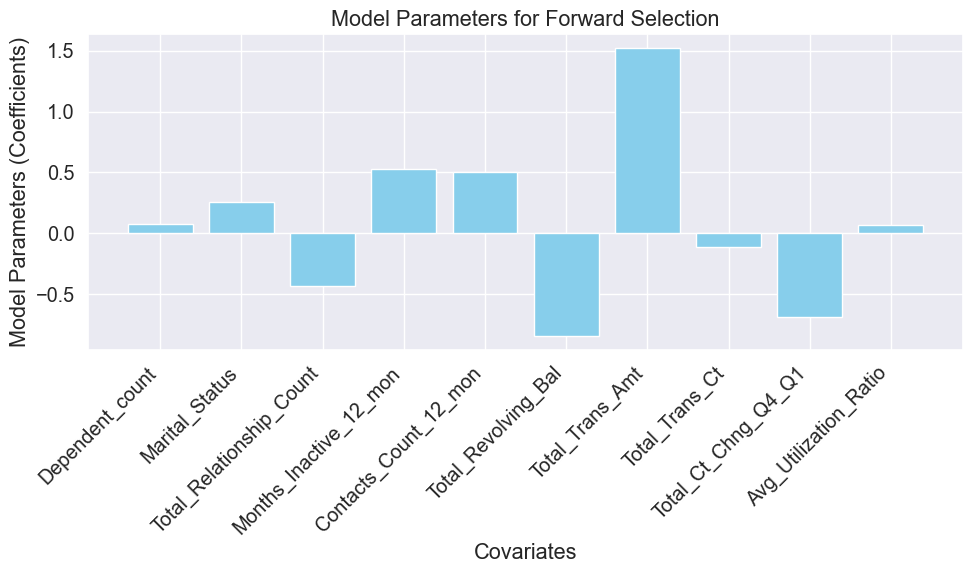

```python
import matplotlib.pyplot as plt

feature_names = forward_selected_feature_names
coefficients = logreg.coef_.flatten()

# Create a bar plot
plt.figure(figsize=(10, 6))
plt.bar(feature_names, coefficients, color='skyblue')
plt.xlabel('Covariates')
plt.ylabel('Model Parameters (Coefficients)')
plt.xticks(rotation=45, ha="right")
plt.title('Model Parameters for Forward Selection')
plt.tight_layout()  # Adjust layout to make room for the rotated x-axis labels

# Show plot
plt.show()
```

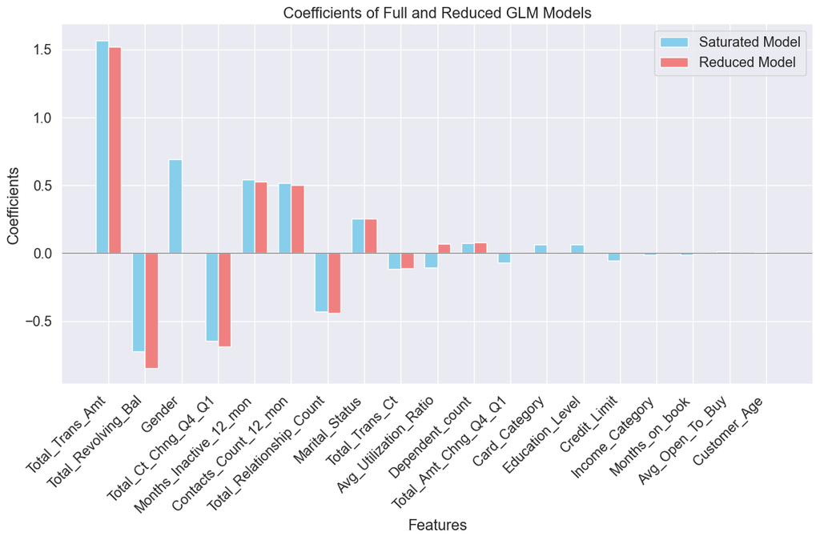

```python
import matplotlib.pyplot as plt
import pandas as pd
import numpy as np

# Create DataFrame from the reduced model
reduced_model_df = pd.DataFrame({
    'Feature': forward_selected_feature_names,
    'Coefficient_Reduced': logreg.coef_.flatten()
})

# Set the index to 'Feature' for easier combination
reduced_model_df.set_index('Feature', inplace=True)

# Create DataFrame from the full model
full_model_df = pd.DataFrame(feature_coefficients)

# Set the index to 'Feature' for easier combination
full_model_df.set_index('Feature', inplace=True)

# Combine the two DataFrames
combined_df = full_model_df.join(reduced_model_df, how='outer')

# If a feature is not in the reduced model, set its coefficient to zero
combined_df['Coefficient_Reduced'].fillna(0, inplace=True)

# Sort by the absolute values of the full model's coefficients in descending order
combined_df['abs_Coefficient'] = combined_df['Coefficient'].abs()
combined_df.sort_values(by='abs_Coefficient', ascending=False, inplace=True)
combined_df.drop('abs_Coefficient', axis=1, inplace=True)

# Plot
fig, ax = plt.subplots(figsize=(12, 8))

# The x locations for the groups
ind = np.arange(len(combined_df))

# Bar width
width = 0.35

p1 = ax.bar(ind, combined_df['Coefficient'], width, color='skyblue', label='Saturated Model')
p2 = ax.bar(ind + width, combined_df['Coefficient_Reduced'], width, color='lightcoral', label='Reduced Model')

ax.axhline(0, color='grey', linewidth=0.8)
ax.set_title('Coefficients of Full and Reduced GLM Models')
ax.set_xticks(ind + width / 2)
ax.set_xticklabels(combined_df.index, rotation=45, ha="right")
ax.set_xlabel('Features')
ax.set_ylabel('Coefficients')
plt.legend((p1[0], p2[0]), ('Saturated Model', 'Reduced Model'))
plt.tight_layout()

plt.show()
```

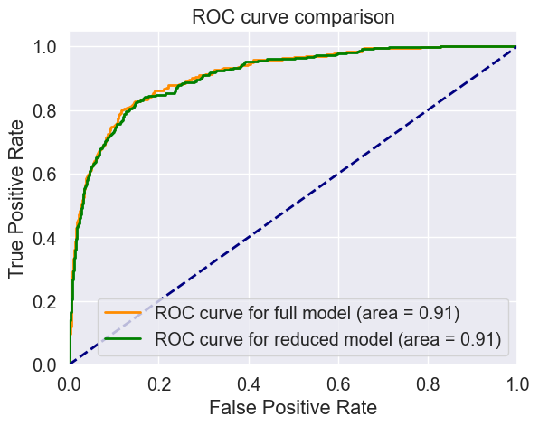

```python
from sklearn.linear_model import LogisticRegression
from sklearn.feature_selection import SequentialFeatureSelector
from sklearn.metrics import roc_curve, auc
import matplotlib.pyplot as plt

# Fit the Logistic Regression model on the selected features
logreg.fit(X_train.iloc[:, list(sfs_forward.k_feature_idx_)], y_train)

# Predict probabilities for the Logistic Regression model
y_pred_prob_logreg = logreg.predict_proba(X_val.iloc[:, list(sfs_forward.k_feature_idx_)])[:, 1]

# Compute ROC curve and ROC area for Logistic Regression
fpr_logreg, tpr_logreg, _ = roc_curve(y_val, y_pred_prob_logreg)
roc_auc_logreg = auc(fpr_logreg, tpr_logreg)

# Existing model probabilities and ROC computation
y_pred_prob = model.predict_proba(X_val)[:, 1]
fpr, tpr, _ = roc_curve(y_val, y_pred_prob)
roc_auc = auc(fpr, tpr)

# Plotting both ROC curves
plt.figure()
# Original model ROC curve
plt.plot(fpr, tpr, color='darkorange', lw=2, label='ROC curve for full model (area = %0.2f)' % roc_auc)
# Logistic Regression ROC curve
plt.plot(fpr_logreg, tpr_logreg, color='green', lw=2, label='ROC curve for reduced model (area = %0.2f)' % roc_auc_logreg)
# Diagonal 45-degree line
plt.plot([0, 1], [0, 1], color='navy', lw=2, linestyle='--')
# Axes limits and labels
plt.xlim([0.0, 1.0])
plt.ylim([0.0, 1.05])
plt.xlabel('False Positive Rate')
plt.ylabel('True Positive Rate')
# Title and legend
plt.title('ROC curve comparison')
plt.legend(loc="lower right")
# Show the plot
plt.show()
```

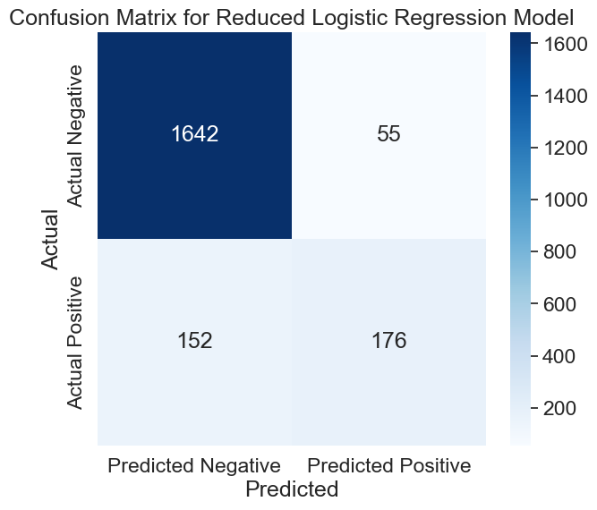

```python
from sklearn.metrics import confusion_matrix
import seaborn as sns
import matplotlib.pyplot as plt

# Make predictions on the validation set
y_pred_logreg = logreg.predict(X_val.iloc[:, list(sfs_forward.k_feature_idx_)])

# Generate the confusion matrix
cm_logreg = confusion_matrix(y_val, y_pred_logreg)

# Plotting the confusion matrix
plt.figure(figsize=(7, 6))
sns.set(font_scale=1.5)  # Adjust to suitable font scale
ax = sns.heatmap(cm_logreg, annot=True, fmt='d', cmap='Blues',
                 xticklabels=['Predicted Negative', 'Predicted Positive'],
                 yticklabels=['Actual Negative', 'Actual Positive'])
plt.ylabel('Actual')
plt.xlabel('Predicted')
plt.title('Confusion Matrix for Reduced Logistic Regression Model')
plt.show()
```

```python
# 'model' is our trained Logistic Regression model
coefficients = model.coef_[0]
features = X.columns

# Pairing each feature with its coefficient
feature_coefficients = pd.DataFrame(zip(features, coefficients), columns=['Feature', 'Coefficient']).sort_values(by='Coefficient', ascending=False)
print(feature_coefficients)
```

```
                     Feature  Coefficient
15           Total_Trans_Amt     1.566514
1                     Gender     0.688676
9     Months_Inactive_12_mon     0.541984
10     Contacts_Count_12_mon     0.515431
4             Marital_Status     0.251645
2            Dependent_count     0.075761
6              Card_Category     0.065268
3            Education_Level     0.064754
13           Avg_Open_To_Buy     0.010226
0               Customer_Age     0.009278
7             Months_on_book    -0.014440
5            Income_Category    -0.016004
11              Credit_Limit    -0.054710
14      Total_Amt_Chng_Q4_Q1    -0.071601
18     Avg_Utilization_Ratio    -0.108410
16            Total_Trans_Ct    -0.115108
8   Total_Relationship_Count    -0.427701
17       Total_Ct_Chng_Q4_Q1    -0.645265
12       Total_Revolving_Bal    -0.724191
```

A positive coefficient indicates an increase in the likelihood of attrition (customer leaving), while a negative coefficient suggests a decrease in that likelihood (customer staying).

### Top Factors Increasing Likelihood of Attrition

- Total_Trans_Amt (1.566514): The total transaction amount has the strongest positive impact on customer attrition. Higher spending customers are more likely to leave. This could indicate that customers who utilize their accounts more heavily might be more sensitive to service issues or find better offers elsewhere.
- Gender_Female (0.688676): This model suggests gender has a significant impact on attrition, with Female customer being more likely to leave than Male customer. The reasons behind the gender difference in attrition could be multifaceted, involving factors such as differences in financial behavior, product preferences, or experiences with the bank. Understanding the underlying reasons would require further qualitative research.
- Months_Inactive_12_mon (0.541984): Longer periods of inactivity in the last 12 months increase the likelihood of attrition. It seems intuitive that customers who do not use their accounts actively are at a higher risk of leaving.
- Contacts_Count_12_mon (0.515431): A higher number of contacts with the bank over the last 12 months is associated with an increased risk of leaving. This could indicate customer dissatisfaction or issues that were not resolved to the customer's satisfaction.

### Subtle Influences

- Customer_Age (0.009278) and Education_Level (0.064754): These factors have a relatively minor impact on the likelihood of attrition directly. However, their roles should not be overlooked as they could interact with other variables in meaningful ways.

### Insights for Action

- Focus on Engagement: Encouraging active use of accounts and reducing inactivity periods could mitigate attrition risk.
- Improve Customer Service: The positive coefficient for Contacts_Count_12_mon highlights the importance of resolving customer issues effectively to prevent them from leaving.
- Leverage Customer Data: Understanding the specific needs and behaviors of customers with high Total_Trans_Amt and adapting services to them could help in retention.
- Enhance Loyalty Programs: Strengthening loyalty programs, especially for customers with a high Total_Relationship_Count and Total_Revolving_Bal, could enhance retention.

```
Decision Tree Accuracy: 0.9012345679012346
Decision Tree ROC-AUC: 0.902943860758584
Confusion Matrix:
 [[1596  101]
 [  99  229]]
Classification Report:
               precision    recall  f1-score   support

           0       0.94      0.94      0.94      1697
           1       0.69      0.70      0.70       328

    accuracy                           0.90      2025
   macro avg       0.82      0.82      0.82      2025
weighted avg       0.90      0.90      0.90      2025
```

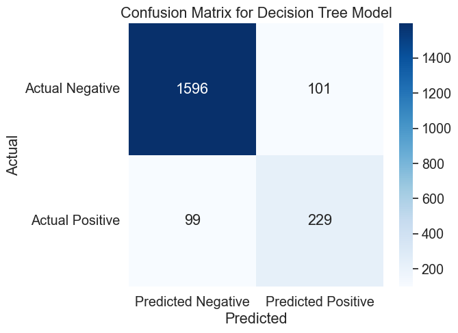

```python
import seaborn as sns
import matplotlib.pyplot as plt
from sklearn.tree import DecisionTreeClassifier
from sklearn.metrics import accuracy_score, roc_auc_score, confusion_matrix, classification_report

# Initialize the model with a maximum depth and minimum samples per split
dt_model = DecisionTreeClassifier(max_depth=3, min_samples_split=50, random_state=42)

# Fit the model
dt_model.fit(X_train, y_train)

# Predictions
y_pred_dt = dt_model.predict(X_val)
y_pred_proba_dt = dt_model.predict_proba(X_val)[:, 1]

# Evaluation
print("Decision Tree Accuracy:", accuracy_score(y_val, y_pred_dt))
print("Decision Tree ROC-AUC:", roc_auc_score(y_val, y_pred_proba_dt))
print("Confusion Matrix:\n", confusion_matrix(y_val, y_pred_dt))
print("Classification Report:\n", classification_report(y_val, y_pred_dt))

# Plotting the confusion matrix
cm = confusion_matrix(y_val, y_pred_dt)
# Set the font scale (this will increase the size of the numbers in each square)
sns.set(font_scale=1.3)  # Example scale factor, adjust as needed

# Adjust the figsize to make the plot smaller
plt.figure(figsize=(6, 5))  # Decrease the figure size
ax = sns.heatmap(cm, annot=True, fmt='d', cmap='Blues', xticklabels=['Predicted Negative', 'Predicted Positive'], yticklabels=['Actual Negative', 'Actual Positive'])
ax.set_xticklabels(['Predicted Negative', 'Predicted Positive'], rotation=0)  # Set rotation to 0 for horizontal labels
ax.set_yticklabels(['Actual Negative', 'Actual Positive'], rotation=0)        # Also setting y-tick labels for consistency

plt.ylabel('Actual')
plt.xlabel('Predicted')
plt.title('Confusion Matrix for Decision Tree Model')
plt.show()
```

- The model's overall accuracy is 0.9012, meaning it correctly predicts whether a customer will stay or leave about 90.12% of the time.
- ROC-AUC stands for "Receiver Operating Characteristic - Area Under Curve." It's a measure of how well the model distinguishes between two groups: those who stayed and those who left. The score of 0.90 suggests the model does this very well, with a score of 1.0 being perfect.
- Classification Report: This part breaks down the model's performance for each group:

  Class 0 (Existing Customers):

  Precision (0.94): When the model predicts a customer will stay, it's correct 94% of the time.  
  Recall (0.94): Of all the customers who actually stayed, the model correctly identifies 94% of them.

  ```
    F1-score (0.94): A balance between precision and recall, suggesting the model is very consistent in predicting customers who stay.
  ```

Class 1 (Attrited Customers):

```
Precision (0.69): When the model predicts a customer will leave, it's correct 69% of the time.<br>
Recall (0.70): Of all the customers who actually left, the model correctly identifies 70% of them.<br>
F1-score (0.70): Reflects that the model is fairly good but not as strong in predicting customer attrition compared to retention.
```

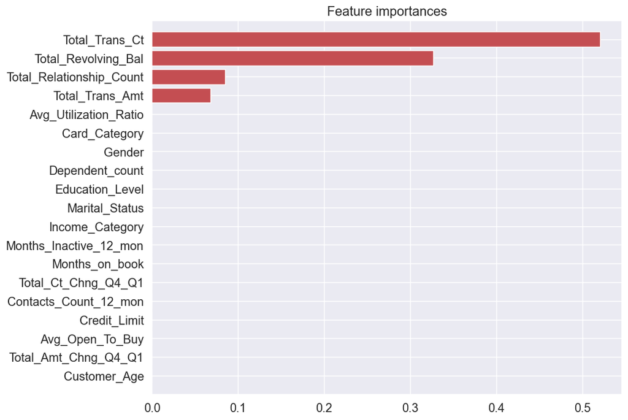

```python
import matplotlib.pyplot as plt
import numpy as np

importances = dt_model.feature_importances_
indices = np.argsort(importances)[::-1]

# Plot the feature importances of the tree horizontally
plt.figure(figsize=(10, 8))  # Adjust the figure size as necessary
plt.title("Feature importances")
plt.barh(range(X_train.shape[1]), importances[indices],
         color="r", align="center")
plt.yticks(range(X_train.shape[1]), X.columns[indices], rotation=0)
plt.ylim([-1, X_train.shape[1]])
plt.gca().invert_yaxis()  # This inverts the y-axis so the most important feature is on top
plt.show()
```

[figure not shown]

```python
from sklearn.tree import export_graphviz
from IPython.display import Image
import graphviz

# Export the decision tree to a dot file
dot_data = export_graphviz(dt_model, out_file=None,
                           feature_names=X_train.columns,
                           class_names=['Attrited Customer', 'Existing Customer'],
                           filled=True, rounded=True,
                           special_characters=True)

# Generate a graph from the dot file and display it
graph = graphviz.Source(dot_data)
Image(graph.pipe(format='png'))
```

```
Best Decision Tree model accuracy on validation set: 0.9328
```

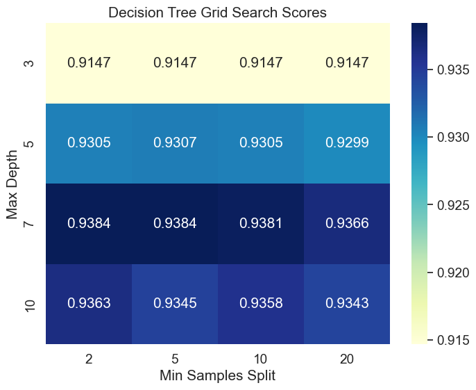

```python
from sklearn.tree import DecisionTreeClassifier
from sklearn.metrics import accuracy_score
from sklearn.model_selection import GridSearchCV
import matplotlib.pyplot as plt
import pandas as pd
import seaborn as sns

# Define the parameter grid
param_grid = {
    'max_depth': [3, 5, 7, 10],  # Example depths
    'min_samples_split': [2, 5, 10, 20],  # Example min samples to split a node
    'random_state': [42]  # Fixed for reproducibility
}

# Initialize the Decision Tree classifier
dt = DecisionTreeClassifier()

# Initialize GridSearchCV
grid_search = GridSearchCV(estimator=dt, param_grid=param_grid, cv=5, scoring='accuracy', n_jobs=-1)

# Fit the grid search to the data
grid_search.fit(X_train, y_train)

# Find the best decision tree model
best_dt_model = grid_search.best_estimator_

# Predictions on validation set using the best model
y_pred_val = best_dt_model.predict(X_val)

# Calculate accuracy on the validation set
accuracy_val = accuracy_score(y_val, y_pred_val)
print(f"Best Decision Tree model accuracy on validation set: {accuracy_val:.4f}")

# Extract the results
results = pd.DataFrame(grid_search.cv_results_)

# Reshape the data for a heatmap plot
results['mean_test_score'] = results['mean_test_score'].round(4)
pivot_table = results.pivot(index='param_max_depth', columns='param_min_samples_split', values='mean_test_score')

# Set the font scale to enlarge font sizes
sns.set(font_scale=1.25)  # Adjust this value as needed to get the desired font size

# Plot a heatmap of mean test scores
plt.figure(figsize=(8, 6))
sns.heatmap(pivot_table, annot=True, fmt=".4g", cmap="YlGnBu")
plt.title('Decision Tree Grid Search Scores')
plt.xlabel('Min Samples Split')
plt.ylabel('Max Depth')
plt.show()

# Don't forget to reset the font scale back to default for other plots if necessary
sns.set(font_scale=1)
```

### Random Forest Model

```python
from sklearn.ensemble import RandomForestClassifier
from sklearn.metrics import accuracy_score, roc_auc_score, confusion_matrix, classification_report

# Initialize the Random Forest classifier
rf_model = RandomForestClassifier(
    n_estimators=100,  # Number of trees in the forest
    max_depth=3,  # Maximum depth of each tree
    min_samples_split=50,  # Minimum number of samples required to split an internal node
    random_state=42  # Ensures a deterministic behavior
)

# Fit the model on the training data
rf_model.fit(X_train, y_train)

# Predictions
y_pred_rf = rf_model.predict(X_val)
y_pred_proba_rf = rf_model.predict_proba(X_val)[:, 1]

# Evaluation
print("Random Forest Accuracy:", accuracy_score(y_val, y_pred_rf))
print("Random Forest ROC-AUC:", roc_auc_score(y_val, y_pred_proba_rf))
print("Classification Report:\n", classification_report(y_val, y_pred_rf))
```

```
Random Forest Accuracy: 0.8819753086419753
Random Forest ROC-AUC: 0.9120183393937652
Classification Report:
               precision    recall  f1-score   support

           0       0.89      0.99      0.93      1697
           1       0.83      0.34      0.48       328

    accuracy                           0.88      2025
   macro avg       0.86      0.66      0.71      2025
weighted avg       0.88      0.88      0.86      2025
```

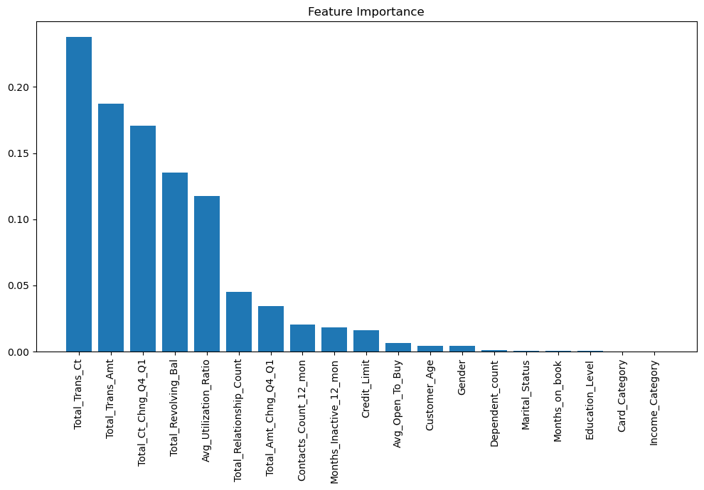

```python
import matplotlib.pyplot as plt
import numpy as np

# rf_model is our trained Random Forest model
feature_importances = rf_model.feature_importances_
# Getting feature names
feature_names = X_train.columns

# Sorting the feature importances in descending order
sorted_indices = np.argsort(feature_importances)[::-1]

plt.figure(figsize=(10, 7))
plt.title('Feature Importance')
plt.bar(range(X_train.shape[1]), feature_importances[sorted_indices], align='center')
plt.xticks(range(X_train.shape[1]), feature_names[sorted_indices], rotation=90)
plt.tight_layout()
plt.show()
```

### Random Forest Model performance

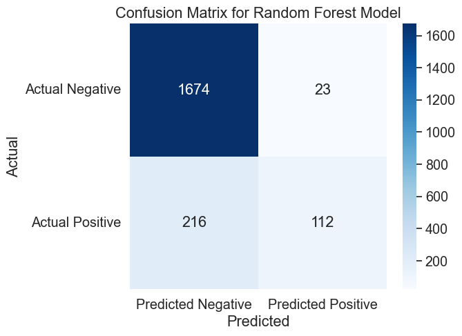

```python
from sklearn.metrics import confusion_matrix
import seaborn as sns
import matplotlib.pyplot as plt

# y_val is true labels and y_pred_rf is model's predictions
cm = confusion_matrix(y_val, y_pred_rf)

# Set the font scale (this will increase the size of the numbers in each square)
sns.set(font_scale=1.3)  # Example scale factor, adjust as needed

# Adjust the figsize to make the plot smaller
plt.figure(figsize=(6, 5))  # Decrease the figure size

# Create the heatmap with the new settings
ax = sns.heatmap(cm, annot=True, fmt='d', cmap='Blues')

# Set the tick labels rotation
ax.set_xticklabels(['Predicted Negative', 'Predicted Positive'], rotation=0)  # Set rotation to 0 for horizontal labels
ax.set_yticklabels(['Actual Negative', 'Actual Positive'], rotation=0)        # Also setting y-tick labels for consistency

# Rest of your plotting code remains the same
plt.ylabel('Actual')
plt.xlabel('Predicted')
plt.title('Confusion Matrix for Random Forest Model')
plt.show()
```

### Random Forest Features vs Decision Tree Features

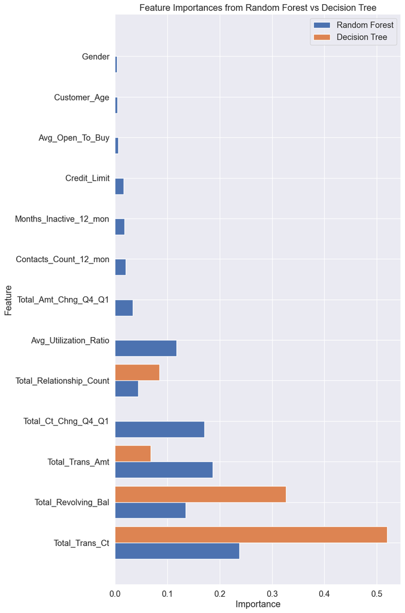

```python
import matplotlib.pyplot as plt
import numpy as np
import pandas as pd

# Get feature importances
rf_importances = rf_model.feature_importances_
dt_importances = dt_model.feature_importances_

# Get feature names
feature_names = X_train.columns.tolist()

# Create a DataFrame for easier comparison
importances_df = pd.DataFrame({
    'Feature': feature_names,
    'RF Importance': rf_importances,
    'DT Importance': dt_importances
})

# Filter by the importance of "Gender" in rf_importances
gender_importance = importances_df.loc[importances_df['Feature'] == 'Gender', 'RF Importance'].iloc[0]
importances_df = importances_df[importances_df['RF Importance'] >= gender_importance]

# Sort by the mean importance from both models
importances_df['Mean Importance'] = importances_df[['RF Importance', 'DT Importance']].mean(axis=1)
importances_df.sort_values(by='Mean Importance', ascending=False, inplace=True)

# Make sure feature names are in string format for plotting
importances_df['Feature'] = importances_df['Feature'].astype(str)

# Plot the feature importances of the random forest and decision tree, switching x and y axes
plt.figure(figsize=(10, 15))

y_values = np.arange(len(importances_df['Feature']))
width = 0.4  # Width of the bars

plt.barh(y_values - width/2, importances_df['RF Importance'], height=width, label='Random Forest')
plt.barh(y_values + width/2, importances_df['DT Importance'], height=width, label='Decision Tree')

plt.yticks(ticks=y_values, labels=importances_df['Feature'])
plt.xlabel('Importance')
plt.ylabel('Feature')
plt.title('Feature Importances from Random Forest vs Decision Tree')
plt.legend()
plt.tight_layout()
plt.show()
```

### Using neural network for predicting the attrition

```python
import tensorflow as tf
from tensorflow.keras.models import Sequential
from tensorflow.keras.layers import Dense, Dropout
from tensorflow.keras.optimizers import Adam

# Define the model architecture
model = Sequential([
    Dense(128, input_dim=X_train.shape[1], activation='relu'),  # Layer with 128 neurons and ReLU activation
    Dropout(0.2),  # Dropout for regularization
    Dense(64, activation='relu'),  # Another hidden layer
    Dropout(0.2),
    Dense(1, activation='sigmoid')  # Output layer with sigmoid activation for binary classification
])

# Compile the model
model.compile(loss='binary_crossentropy',  # Loss function for binary classification
              optimizer=Adam(learning_rate=0.001),  # Optimizer with learning rate
              metrics=['accuracy'])  # Metric to evaluate model

# Train the model
history = model.fit(X_train, y_train, epochs=50, batch_size=32, validation_data=(X_val, y_val), verbose=2)

# Evaluate the model on the test set
test_loss, test_accuracy = model.evaluate(X_test, y_test)
print(f"Test Loss: {test_loss}, Test Accuracy: {test_accuracy}")
```

```
WARNING:absl:At this time, the v2.11+ optimizer `tf.keras.optimizers.Adam` runs slowly on M1/M2 Macs, please use the legacy Keras optimizer instead, located at `tf.keras.optimizers.legacy.Adam`.
```

```
190/190 - 0s - loss: 0.5364 - accuracy: 0.8204 - val_loss: 0.4131 - val_accuracy: 0.8370 - 444ms/epoch - 2ms/step
190/190 - 0s - loss: 0.3385 - accuracy: 0.8519 - val_loss: 0.3150 - val_accuracy: 0.8607 - 106ms/epoch - 560us/step
190/190 - 0s - loss: 0.2989 - accuracy: 0.8766 - val_loss: 0.2922 - val_accuracy: 0.8968 - 108ms/epoch - 567us/step
190/190 - 0s - loss: 0.2761 - accuracy: 0.8861 - val_loss: 0.2639 - val_accuracy: 0.9002 - 107ms/epoch - 561us/step
190/190 - 0s - loss: 0.2632 - accuracy: 0.8986 - val_loss: 0.2721 - val_accuracy: 0.8983 - 106ms/epoch - 559us/step
190/190 - 0s - loss: 0.2513 - accuracy: 0.9021 - val_loss: 0.2601 - val_accuracy: 0.8948 - 108ms/epoch - 569us/step
190/190 - 0s - loss: 0.2431 - accuracy: 0.9036 - val_loss: 0.2467 - val_accuracy: 0.9007 - 110ms/epoch - 577us/step
190/190 - 0s - loss: 0.2358 - accuracy: 0.9101 - val_loss: 0.2465 - val_accuracy: 0.9002 - 108ms/epoch - 569us/step
190/190 - 0s - loss: 0.2349 - accuracy: 0.9096 - val_loss: 0.2490 - val_accuracy: 0.9057 - 109ms/epoch - 573us/step
190/190 - 0s - loss: 0.2223 - accuracy: 0.9128 - val_loss: 0.2499 - val_accuracy: 0.9027 - 106ms/epoch - 558us/step
190/190 - 0s - loss: 0.2294 - accuracy: 0.9106 - val_loss: 0.2347 - val_accuracy: 0.9077 - 108ms/epoch - 567us/step
190/190 - 0s - loss: 0.2189 - accuracy: 0.9115 - val_loss: 0.2332 - val_accuracy: 0.9116 - 105ms/epoch - 554us/step
190/190 - 0s - loss: 0.2141 - accuracy: 0.9136 - val_loss: 0.2282 - val_accuracy: 0.9047 - 105ms/epoch - 550us/step
190/190 - 0s - loss: 0.2134 - accuracy: 0.9177 - val_loss: 0.2311 - val_accuracy: 0.9121 - 106ms/epoch - 556us/step
190/190 - 0s - loss: 0.2101 - accuracy: 0.9198 - val_loss: 0.2334 - val_accuracy: 0.8973 - 108ms/epoch - 569us/step
190/190 - 0s - loss: 0.2113 - accuracy: 0.9167 - val_loss: 0.2212 - val_accuracy: 0.9096 - 104ms/epoch - 548us/step
190/190 - 0s - loss: 0.2012 - accuracy: 0.9207 - val_loss: 0.2226 - val_accuracy: 0.9106 - 104ms/epoch - 548us/step
190/190 - 0s - loss: 0.2022 - accuracy: 0.9187 - val_loss: 0.2291 - val_accuracy: 0.9072 - 105ms/epoch - 551us/step
190/190 - 0s - loss: 0.2015 - accuracy: 0.9223 - val_loss: 0.2212 - val_accuracy: 0.9141 - 105ms/epoch - 552us/step
190/190 - 0s - loss: 0.2023 - accuracy: 0.9190 - val_loss: 0.2203 - val_accuracy: 0.9106 - 125ms/epoch - 656us/step
190/190 - 0s - loss: 0.1968 - accuracy: 0.9208 - val_loss: 0.2234 - val_accuracy: 0.9106 - 108ms/epoch - 567us/step
190/190 - 0s - loss: 0.1925 - accuracy: 0.9226 - val_loss: 0.2197 - val_accuracy: 0.9121 - 126ms/epoch - 663us/step
190/190 - 0s - loss: 0.1898 - accuracy: 0.9269 - val_loss: 0.2190 - val_accuracy: 0.9151 - 106ms/epoch - 556us/step
190/190 - 0s - loss: 0.1890 - accuracy: 0.9225 - val_loss: 0.2082 - val_accuracy: 0.9180 - 106ms/epoch - 559us/step
190/190 - 0s - loss: 0.1885 - accuracy: 0.9273 - val_loss: 0.2052 - val_accuracy: 0.9215 - 105ms/epoch - 554us/step
190/190 - 0s - loss: 0.1811 - accuracy: 0.9276 - val_loss: 0.2207 - val_accuracy: 0.9126 - 106ms/epoch - 556us/step
190/190 - 0s - loss: 0.1830 - accuracy: 0.9296 - val_loss: 0.2488 - val_accuracy: 0.9067 - 106ms/epoch - 559us/step
190/190 - 0s - loss: 0.1832 - accuracy: 0.9276 - val_loss: 0.2083 - val_accuracy: 0.9195 - 107ms/epoch - 563us/step
190/190 - 0s - loss: 0.1791 - accuracy: 0.9301 - val_loss: 0.2090 - val_accuracy: 0.9146 - 107ms/epoch - 565us/step
190/190 - 0s - loss: 0.1767 - accuracy: 0.9282 - val_loss: 0.2199 - val_accuracy: 0.9081 - 108ms/epoch - 567us/step
190/190 - 0s - loss: 0.1755 - accuracy: 0.9315 - val_loss: 0.2047 - val_accuracy: 0.9235 - 107ms/epoch - 562us/step
190/190 - 0s - loss: 0.1705 - accuracy: 0.9312 - val_loss: 0.2025 - val_accuracy: 0.9205 - 106ms/epoch - 557us/step
190/190 - 0s - loss: 0.1694 - accuracy: 0.9322 - val_loss: 0.2125 - val_accuracy: 0.9116 - 105ms/epoch - 554us/step
190/190 - 0s - loss: 0.1700 - accuracy: 0.9342 - val_loss: 0.1962 - val_accuracy: 0.9230 - 104ms/epoch - 549us/step
190/190 - 0s - loss: 0.1639 - accuracy: 0.9370 - val_loss: 0.2032 - val_accuracy: 0.9151 - 111ms/epoch - 583us/step
190/190 - 0s - loss: 0.1690 - accuracy: 0.9338 - val_loss: 0.2024 - val_accuracy: 0.9190 - 105ms/epoch - 552us/step
190/190 - 0s - loss: 0.1614 - accuracy: 0.9365 - val_loss: 0.2008 - val_accuracy: 0.9225 - 104ms/epoch - 547us/step
190/190 - 0s - loss: 0.1664 - accuracy: 0.9348 - val_loss: 0.1961 - val_accuracy: 0.9230 - 105ms/epoch - 554us/step
190/190 - 0s - loss: 0.1608 - accuracy: 0.9380 - val_loss: 0.1996 - val_accuracy: 0.9215 - 105ms/epoch - 554us/step
190/190 - 0s - loss: 0.1571 - accuracy: 0.9389 - val_loss: 0.2146 - val_accuracy: 0.9121 - 104ms/epoch - 547us/step
190/190 - 0s - loss: 0.1593 - accuracy: 0.9376 - val_loss: 0.1870 - val_accuracy: 0.9254 - 103ms/epoch - 542us/step
190/190 - 0s - loss: 0.1511 - accuracy: 0.9393 - val_loss: 0.1924 - val_accuracy: 0.9170 - 104ms/epoch - 546us/step
190/190 - 0s - loss: 0.1571 - accuracy: 0.9391 - val_loss: 0.1878 - val_accuracy: 0.9264 - 106ms/epoch - 557us/step
190/190 - 0s - loss: 0.1501 - accuracy: 0.9431 - val_loss: 0.1881 - val_accuracy: 0.9240 - 106ms/epoch - 557us/step
190/190 - 0s - loss: 0.1530 - accuracy: 0.9409 - val_loss: 0.1915 - val_accuracy: 0.9244 - 103ms/epoch - 543us/step
190/190 - 0s - loss: 0.1500 - accuracy: 0.9389 - val_loss: 0.1875 - val_accuracy: 0.9240 - 105ms/epoch - 555us/step
190/190 - 0s - loss: 0.1553 - accuracy: 0.9393 - val_loss: 0.2237 - val_accuracy: 0.9146 - 119ms/epoch - 625us/step
190/190 - 0s - loss: 0.1496 - accuracy: 0.9426 - val_loss: 0.1909 - val_accuracy: 0.9240 - 108ms/epoch - 570us/step
190/190 - 0s - loss: 0.1526 - accuracy: 0.9411 - val_loss: 0.1829 - val_accuracy: 0.9264 - 105ms/epoch - 551us/step
190/190 - 0s - loss: 0.1497 - accuracy: 0.9431 - val_loss: 0.1837 - val_accuracy: 0.9279 - 104ms/epoch - 549us/step
Test Loss: 0.1618322879076004, Test Accuracy: 0.9427443146705627
```

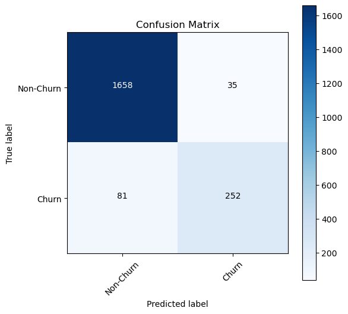

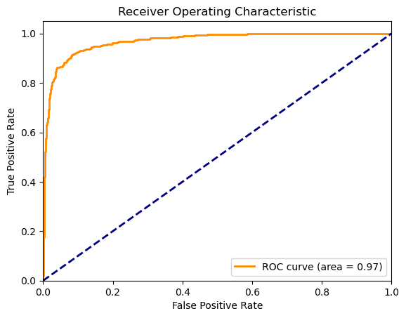

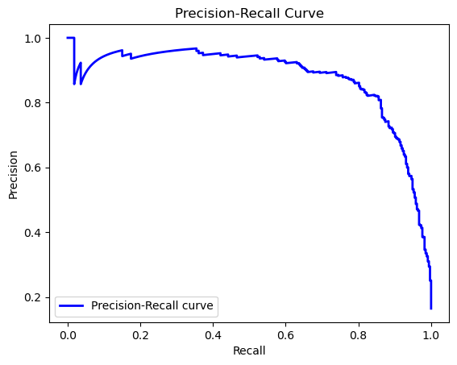

```
              precision    recall  f1-score   support

   Non-Churn       0.95      0.98      0.97      1693
       Churn       0.88      0.76      0.81       333

    accuracy                           0.94      2026
   macro avg       0.92      0.87      0.89      2026
weighted avg       0.94      0.94      0.94      2026
```

```python
import numpy as np
import matplotlib.pyplot as plt
from sklearn.metrics import confusion_matrix, roc_curve, auc, precision_recall_curve, classification_report

# Predict probabilities for the test set
y_probs = model.predict(X_test)
y_pred = (y_probs > 0.5).astype(int)  # Convert probabilities to binary output

# Confusion Matrix
conf_matrix = confusion_matrix(y_test, y_pred)
plt.figure(figsize=(6,6))
plt.imshow(conf_matrix, interpolation='nearest', cmap=plt.cm.Blues)
plt.title('Confusion Matrix')
plt.colorbar()
tick_marks = np.arange(2)
plt.xticks(tick_marks, ['Non-Churn', 'Churn'], rotation=45)
plt.yticks(tick_marks, ['Non-Churn', 'Churn'])
plt.xlabel('Predicted label')
plt.ylabel('True label')
plt.grid(False)
for i, j in np.ndindex(conf_matrix.shape):
    plt.text(j, i, conf_matrix[i, j], horizontalalignment='center', color='white' if conf_matrix[i, j] > conf_matrix.max()/2 else 'black')
plt.show()

# ROC Curve
fpr, tpr, thresholds = roc_curve(y_test, y_probs)
roc_auc = auc(fpr, tpr)
plt.figure()
plt.plot(fpr, tpr, color='darkorange', lw=2, label='ROC curve (area = %0.2f)' % roc_auc)
plt.plot([0, 1], [0, 1], color='navy', lw=2, linestyle='--')
plt.xlim([0.0, 1.0])
plt.ylim([0.0, 1.05])
plt.xlabel('False Positive Rate')
plt.ylabel('True Positive Rate')
plt.title('Receiver Operating Characteristic')
plt.legend(loc="lower right")
plt.show()

# Precision-Recall Curve
precision, recall, _ = precision_recall_curve(y_test, y_probs)
plt.figure()
plt.plot(recall, precision, color='blue', lw=2, label='Precision-Recall curve')
plt.xlabel('Recall')
plt.ylabel('Precision')
plt.title('Precision-Recall Curve')
plt.legend(loc="lower left")
plt.show()

# Classification Report
class_report = classification_report(y_test, y_pred, target_names=['Non-Churn', 'Churn'])
print(class_report)
```

**Confusion Matrix:**

- The matrix shows 1,658 true negatives, where the model correctly predicted 'Non-Churn'.
- There are 35 false positives, where the model incorrectly predicted 'Churn' instead of 'Non-Churn'.
- The model predicted 'Churn' correctly 252 times, which are true positives.
- There are 81 false negatives, where 'Churn' was the true class, but the model predicted 'Non-Churn'.

**Receiver Operating Characteristic (ROC) Curve:**

- The ROC curve is close to the top left corner, indicating a high true positive rate and low false positive rate.
- The area under the ROC curve (AUC) is 0.97, suggesting the model has excellent discrimination capabilities between 'Churn' and 'Non-Churn'.
- The curve stays far above the diagonal line, which represents a no-skill classifier.

**Precision-Recall Curve:**

- The Precision-Recall curve starts with high precision, indicating that initially, when recall is low, the model is very confident in its positive predictions.
- As recall increases (more true positives are captured), precision decreases, which is typical behavior as the model starts to make more false positive errors.
- The model appears to maintain a high precision until a recall of about 0.8, which is good performance, especially if the positive class ('Churn') is of specific interest and is rarer compared to the negative class ('Non-Churn').